# L08 Positioning

Data Visualization (STAT 302)

Martha Eichlersmith

2020-05-03

```r
library(knitr)
opts_chunk$set(dpi = 300)
```

## Overview

The goal of this lab is to develop an understanding of facets, position, continue the exploration of other `ggplot2` options/features.

## Datasets

We’ll be using the `titanic.rda`, `Aus_athletes.rda`, and `cdc.txt` datasets.

```r
# Load package(s)
library(tidyverse)
library(scales)
library(cowplot)

# Load datasets
load(file = "data/titanic.rda")
load(file = "data/Aus_athletes.rda")

# Read in the cdc dataset
cdc <- read_delim(file = "data/cdc.txt", delim = "|") %>%
  mutate(genhlth = factor(genhlth,
    levels = c("excellent", "very good", "good", "fair", "poor"),
    labels = c("Excellent", "Very Good", "Good", "Fair", "Poor")
  ))

# Set seed
set.seed(8221984)

# Selecting a random subset of size 1000
cdc_small <- cdc %>% sample_n(1000)
```

## Exercises

### Exercise 1

The following plot uses the `titanic.rda` dataset .

*Hints:*

- Hex colors: `#D55E00D0`, `#0072B2D0`

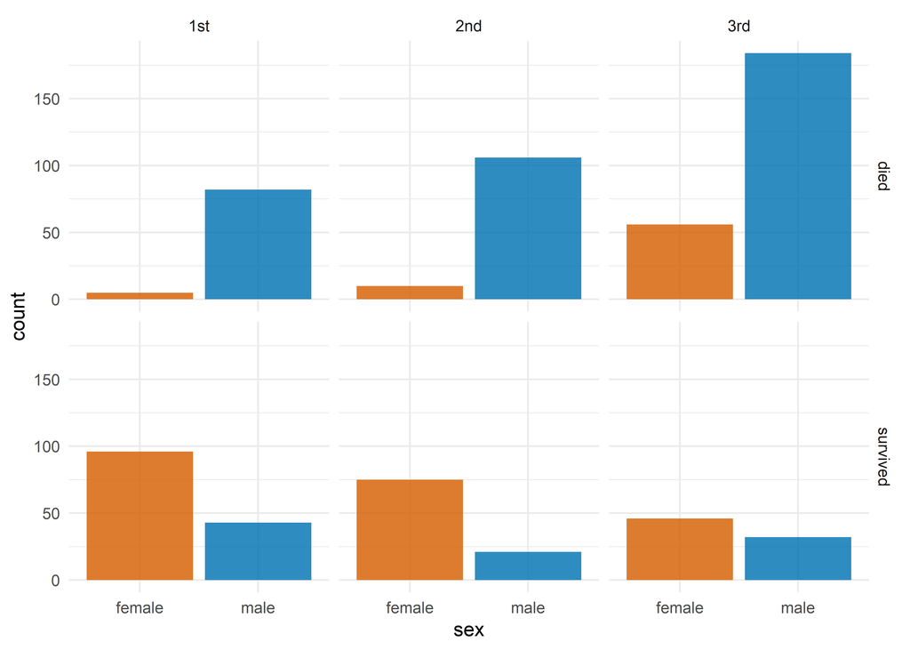

```r
ggplot(titanic, aes(sex, fill = sex)) +
  geom_bar() +
  facet_grid(
    factor(survived, labels = c("died", "survived"))
    ~
    class
  ) +
  scale_fill_manual(values = c("#D55E00D0", "#0072B2D0")) +
  theme_minimal() +
  theme(legend.position = "none")
```

### Exercise 2

Use the `athletes_dat` dataset — extracted from `Aus_althetes.rd` — to recreate the following graphic as precisely as possible. The `cowplot` package will be useful.

```r
# Get list of sports played by BOTH sexes
both_sports <- Aus_athletes %>%
  distinct(sex, sport) %>%
  count(sport) %>%
  filter(n == 2) %>%
  pull(sport)

# Process data
athletes_dat <- Aus_athletes %>%
  filter(sport %in% both_sports) %>%
  mutate(sport = case_when(
    sport == "track (400m)" ~ "track",
    sport == "track (sprint)" ~ "track",
    TRUE ~ sport
    )
  )
```

*Hints:*

- Build each plot separately
- Use [`cowplot::plot_grid()`](https://cran.r-project.org/web/packages/cowplot/vignettes/plot_grid.html) to combine them
- Hex values for shading: `#D55E0040` and `#0072B240` (bottom plot), `#D55E00D0` & `#0072B2D0` (for top two plots) — no `alpha`
- Hex values for outline of boxplots: `#D55E00` and `#0072B2`
- Boxplots should be made narrower; 0.5
- Legend is in top-right corner of bottom plot
- Legend shading matches hex values for top two plots
- Bar plot lower limit 0, upper limit 95
- `rcc`: red blood cell count; `wcc`: white blood cell count
- Size 3 will be useful

```r
plotA <- ggplot(athletes_dat, aes(sex, fill = sex)) +
  geom_bar(show.legend = FALSE)+
  scale_fill_manual(values = c("#D55E00D0", "#0072B2D0")) +
  scale_x_discrete(
      name = NULL
    , labels = c("female", "male")
  ) +
  scale_y_continuous(
      name = "number"
    , breaks = seq(0, 100, 25)
    , limits = c(0, 95)
  ) +
  theme_minimal()
```

```r
plotB <- ggplot(athletes_dat, aes(rcc, wcc)) +
  geom_point(
      aes(fill = sex)
    , shape = 21
    , color = "white"
    , size = 3
    , show.legend = FALSE
    ) +
  scale_fill_manual(values = c("#D55E00D0", "#0072B2D0")) +
  scale_x_continuous(name = "RBC Count") +
  scale_y_continuous(name = "WBC count") +
  theme_minimal()
```

```r
sex_labs <- c("female", "male")

plotC <- ggplot(athletes_dat, aes(sport, pcBfat)) +
  geom_boxplot(
      aes(color = sex, fill = sex)
    , width = 0.5
    ) +
  scale_fill_manual(
      name = NULL
    , labels = sex_labs
    , values = c("#D55E0040", "#0072B240")) +
  scale_color_manual(
      name = NULL
    , labels = sex_labs
    , values = c("#D55E00D0", "#0072B2D0")) +
  guides(fill = guide_legend(
      ncol = 2
    , override.aes = list(
        fill = c("#D55E00D0", "#0072B2D0")
      , color = "transparent"
      )
    )
  ) +
  xlab(NULL) +
  ylab("% body fat") +
  theme_minimal() +
  theme(
      legend.position = c(1, 1)
    , legend.justification = c(1, 1)
    #set top legend to zero
    , legend.margin = margin(t = 0)
  )
```

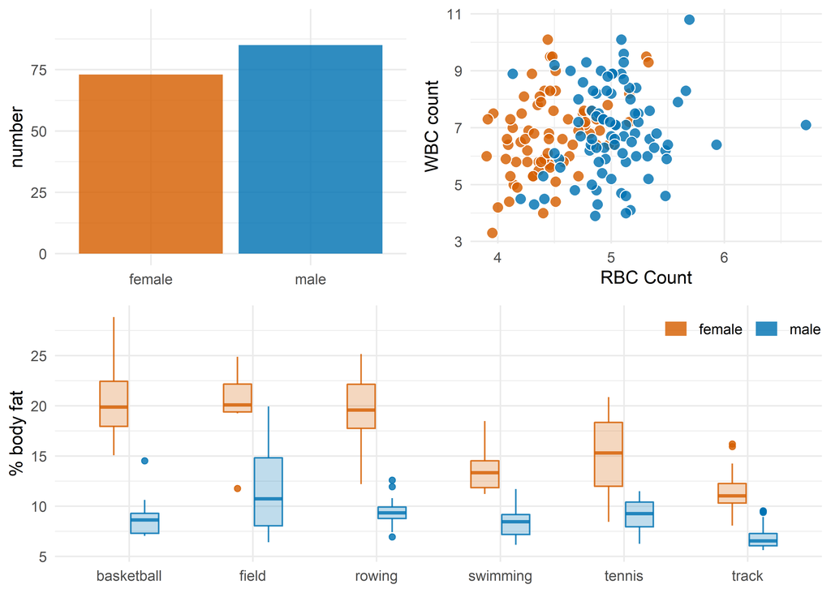

```r
plot_grid(
    plot_grid(plotA, plotB, nrow = 1)
  , plotC
  , nrow = 2
)
```

### Exercise 3

Using `cdc_small`construct a the following graphic as precisely as possible.

*Hints:*

- Need to do a little more data processing
- Hex values: `"#D55E00D0"` and `#0072B2D0`
- `grey80` might be useful
- size 2

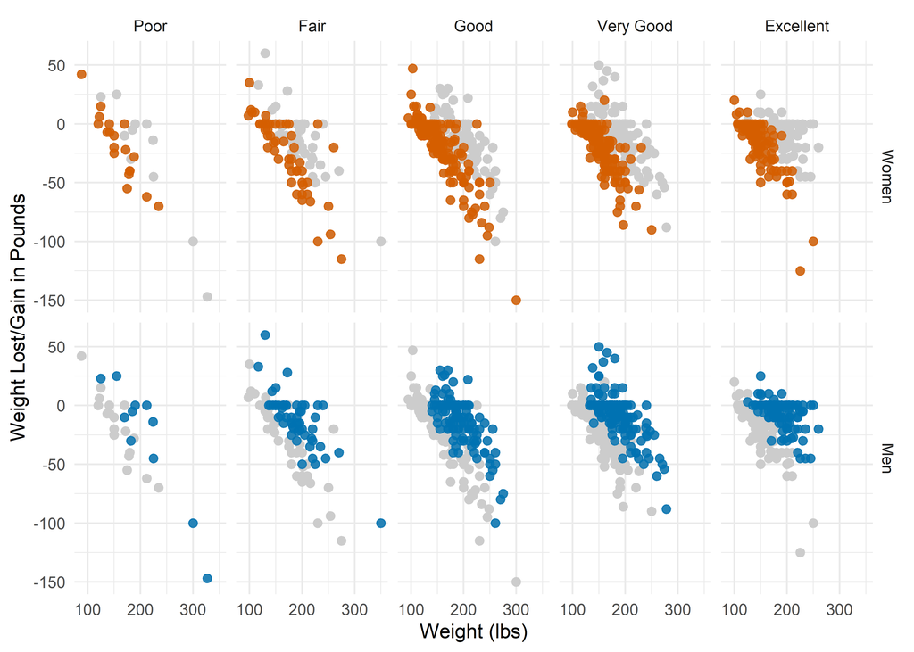

```r
cdc_small_adj <- cdc_small %>%
  mutate(wtloss = wtdesire - weight)


ggplot(cdc_small_adj, aes(weight, wtloss)) +
  geom_point(
      data = select(cdc_small_adj, -gender)
    , color = "grey80"
    , size = 2
  ) +
  geom_point(
      aes(color = gender)
    , size = 2
    , show.legend = FALSE
  ) +
  scale_color_manual(values = c("#D55E00D0", "#0072B2D0")) +
  facet_grid(
    factor(gender, labels = c("Women", "Men"))
    ~
    fct_rev(genhlth)
  ) +
  xlab("Weight (lbs)") +
  ylab( "Weight Lost/Gain in Pounds") +
  theme_minimal()
```